# ggplot2: 18 Themes

This notebook is based on exercises completed from [ggplot2: Elegant Graphics for Data Analysis](https://ggplot2-book.org/index.html).

```r
library(tidyverse)
```

## 18.2.1 Complete Theme Exercises

1. Try out all the themes in ggthemes. Which do you like the best?

[ggtheme examples](https://yutannihilation.github.io/allYourFigureAreBelongToUs/ggthemes/)

[theme_map] (https://yutannihilation.github.io/allYourFigureAreBelongToUs/ggthemes/theme_map/)

2. What aspects of the default theme do you like? What don’t you like? What would you change?

I prefer theme_bw(). In particular, I always like to change the grey background.

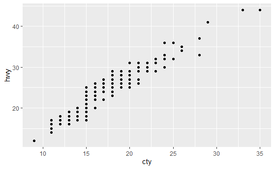

```r
#default theme
ggplot() +
 geom_point(mapping = aes(y = hwy, x = cty), data = mpg)
```

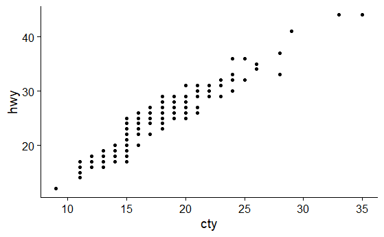

```r
#HDB theme
ggplot() +
 geom_point(mapping = aes(y = hwy, x = cty), data = mpg) +
  theme_cowplot()
```

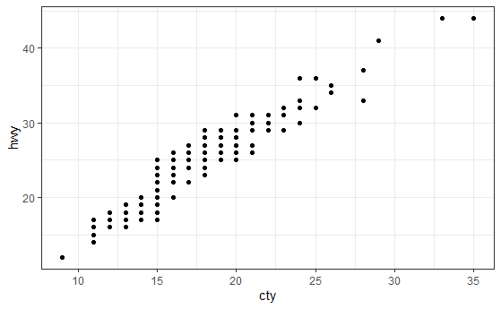

```r
# my favourite theme
ggplot() +
 geom_point(mapping = aes(y = hwy, x = cty), data = mpg) +
  theme_bw()
```

3. Look at the plots in your favourite scientific journal. What theme do they most resemble? What are the main differences?

[Marine Ecological Progress Series](https://www.int-res.com/abstracts/meps/v666/)

[Example Article](https://www.int-res.com/articles/feature/m666p001.pdf)

On page 4,the map is simple with white background, no ticks. On page 8 the graphs are close to them_bw() with a white background and enclosed frame.

## 18.4.6 Theme Elements Exercises

1. Create the ugliest plot possible! (Contributed by Andrew D. Steen, University of Tennessee - Knoxville)

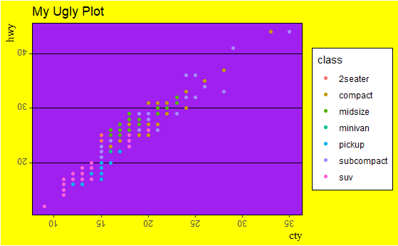

2. theme_dark() makes the inside of the plot dark, but not the outside. Change the plot background to black, and then update the text settings so you can still read the labels.

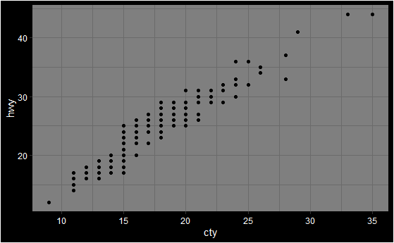

3. Make an elegant theme that uses “linen” as the background colour and a serif font for the text.

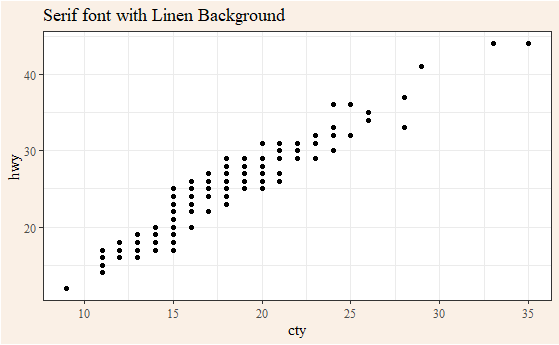

4. Systematically explore the effects of hjust when you have a multiline title. Why doesn’t vjust do anything?

The vjust is constrained but the background of the plot

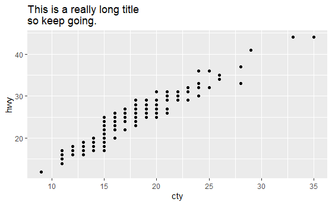

```r
p <- ggplot() +
 geom_point(mapping = aes(y = hwy, x = cty), data = mpg) +
  labs(title = "This is a really long title \nso keep going.")

# baseplot
p
```

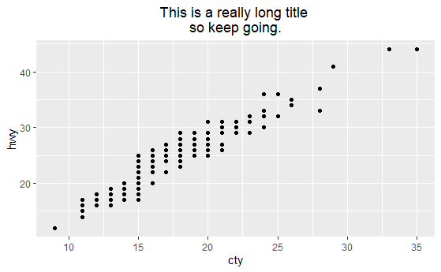

```r
# plot with hjust
p +
  theme(plot.title = element_text(hjust = 0.5))
```

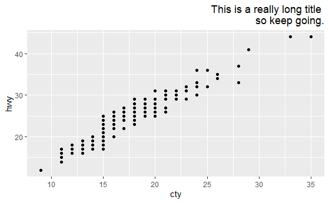

```r
p +
  theme(plot.title = element_text(hjust = 1))
```

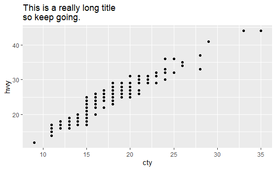

```r
# try vjust
p +
  theme(plot.title = element_text(vjust = 1))
```

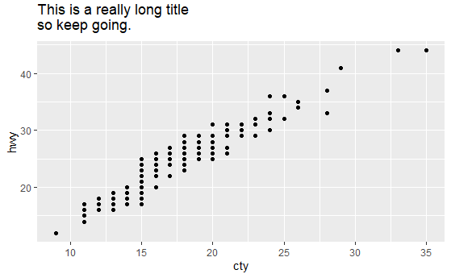

```r
p +
  theme(plot.title = element_text(vjust = 2))
```